# Ford go bike System Data

**Q2:Is there any relationship between the age of the person and duration of riding a bike?**

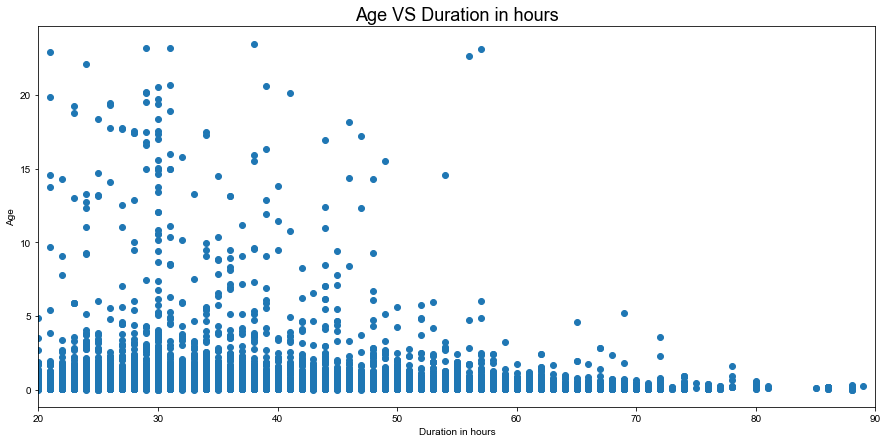

```python
plt.figure(figsize = (15, 7))
plt.scatter(data = df, x = 'Age', y = 'duration_hours' , alpha= 1);
xaxis = plt.gca()
xaxis.set_xlim([20,90])
plt.style.use('seaborn')
plt.xlabel('Duration in hours')
plt.ylabel('Age')
plt.title('Age VS Duration in hours',fontsize = 18)
plt.show();
```

**Interpretation: People around age 30 tend to take the longest rides. Also; the older they became, the less ride duration they did.**

**Q1:For each week of february 2019, what period most often people went riding and what is the hourly duration for them?**

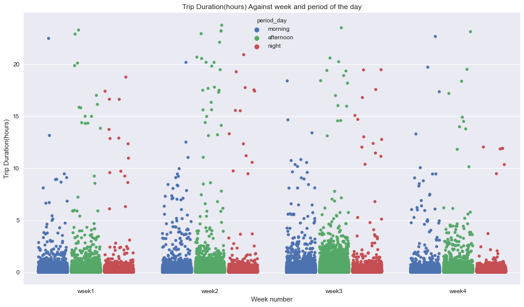

```python
plt.figure(figsize = [14.70 , 8.27])
sb.stripplot(data = df , hue = 'period_day', x = 'week_num' , y = 'duration_hours' ,jitter = 0.35 , dodge = True)
plt.title('Trip Duration(hours) Against week and period of the day')
plt.xlabel('Week number')
plt.ylabel('Trip Duration(hours)')
plt.show();
```

**Most of people had riding with more duration were concentrated in afternoon period especially in first and second weeks of February.**

**Most of morning rides do not exceed 10 hours except for a few of them. However,the third week of february, the number of morning rides increased in compartion with the other weeks.**

**In last week of february,number of night rides reached most bottom and usually that rides extended to 3 hours for all weeks. However,people began to increase the night rides duration in third week**

**In general, rides less crowded in last week and more crowded in middle weeks**

**Q2: For each week of february 2019 , what type of people most often went riding and what is the hourly duration for them?**

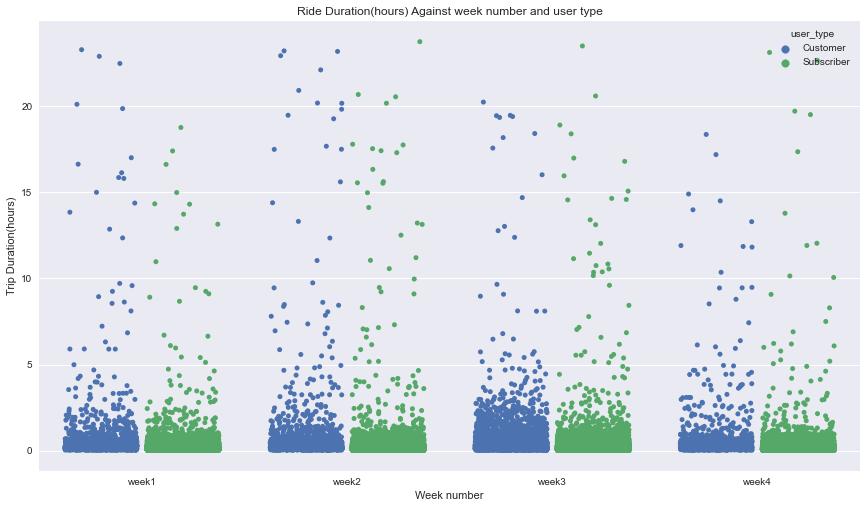

```python
plt.figure(figsize = [14.70 , 8.27])
sb.stripplot(data = df , hue = 'user_type', x = 'week_num' , y = 'duration_hours' ,jitter = 0.35 , dodge = True)
plt.title('Ride Duration(hours) Against week number and user type')
plt.xlabel('Week number')
plt.ylabel('Trip Duration(hours)')
plt.show();
```

**Ride duration for both customer and subscriber in most weeks were approximatly evenly distributed.**

**Q3: what is common start hour across user type in a day for each gender?**

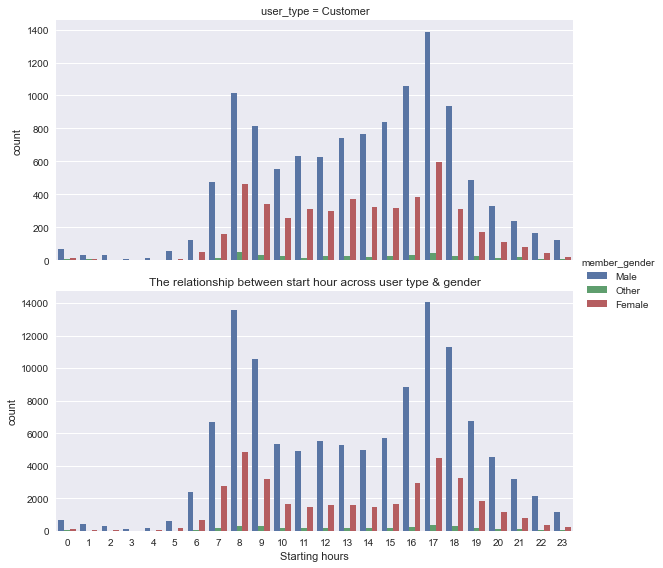

```python
sb.catplot(data=df,x='start_hour',col='user_type',
           hue='member_gender', col_wrap = 1,
           height = 4, aspect=2,
           sharey=False, kind='count')
plt.xlabel('Starting hours')
plt.title('The relationship between start hour across user type & gender')
plt.show();
```